# ML2 - Time Series

Luisa Yanez y Miguel García

25/07/2022

# ML2 - Series Temporales

# 1. Introducción

La práctica a desarrollar consiste en la elaboración y presentación de un informe de un proyecto de Ciencia de Datos, utilizando las técnicas aprendidas durante la asignatura, aplicadas al conjunto de datos seleccionados.

## 1.1. Lenguaje de programación y herramienta de control de versiones utilizado

El grupo eligió trabajar en lenguage R (RStudio version 1.4.1717) y utilizar como herramienta de control de versiones GitHub. El proyecto “/ml2_series temporales” fue creado por Luisa Yánez (usuario “lyanezgu”) y compartido con el otro integrante del grupo, Miguel García (usuario “mgarciasanc2021”).

**Link del proyecto en GitHub:** https://github.com/lyanezgu/ml2_series_temporales

## 1.2. Paquetes de R

```r
library(readr)
library(tidyverse)
library(tsibble)
library(fable)
library(feasts)
library(tsibbledata)
library(VIM)
library(Amelia)
library(imputeTS)
library(gridExtra)
library(dygraphs)
library(ggfortify)
library(vars)
library(ggplot2)
library(lubridate)
library(assertthat)
library(xts)
library(MASS)
library(fpp3)
library(GGally)
library(forecast)
library(tseries)
```

# 2. Conjunto de datos

**Link del dataset:** https://www.kaggle.com/datasets/sumanthvrao/daily-climate-time-series-data?resource=download&select=DailyDelhiClimateTest.csv

## 2.1. Definición de las variables

Empezando ya el análisis inicial del conjunto de datos que tenemos, vemos que las 5 variables que componen los datos pueden ser descritas como:

- **Date:** fecha en formato YYYY-MM-DD
- **meantemp:** temperatura media calculada en intervalos de tres horas por día
- **humidity:** humedad en el día gramos de vapor de agua por volumen en m3 de aire
- **wind_speed:** velocidad del aire medido en km/h
- **meanpreassure:** presión medida en atm

## 2.2. Carga de datos

El conjunto de datos “Daily Climate time series data” contiene 5 columnas y 1575 filas (1461 de train y 114 de test) y lo obtenemos en formato .CSV, de dos ficheros diferentes.

Cargamos entonces los datos ya dividos entre train y test.

```r
clima_train <- read.csv("DailyDelhiClimateTrain.csv",sep = ",")
clima_test <- read.csv("DailyDelhiClimateTest.csv",sep = ",")
```

Inicialmente, el conjunto de datos de entrenamiento, se ha guardado un dataframe llamado “clima_train” y se ha realizado un estudio inicial sobre su contenido utilizando la función head y summary.

```r
head(clima_train)
```

```
##         date  meantemp humidity wind_speed meanpressure
## 1 2013-01-01 10.000000 84.50000   0.000000     1015.667
## 2 2013-01-02  7.400000 92.00000   2.980000     1017.800
## 3 2013-01-03  7.166667 87.00000   4.633333     1018.667
## 4 2013-01-04  8.666667 71.33333   1.233333     1017.167
## 5 2013-01-05  6.000000 86.83333   3.700000     1016.500
## 6 2013-01-06  7.000000 82.80000   1.480000     1018.000
```

Con la función summary vemos en los estadísticos más importantes de las diferentes variables del dataset y observamos que no existe ningún dato faltante (Na).

```r
summary(clima_train)
```

```
##      date              meantemp        humidity       wind_speed
##  Length:1461        Min.   : 6.00   Min.   :13.43   Min.   : 0.000
##  Class :character   1st Qu.:18.86   1st Qu.:50.38   1st Qu.: 3.475
##  Mode  :character   Median :27.71   Median :62.62   Median : 6.250
##                     Mean   :25.51   Mean   :60.74   Mean   : 6.807
##                     3rd Qu.:31.31   3rd Qu.:72.12   3rd Qu.: 9.250
##                     Max.   :38.71   Max.   :98.00   Max.   :42.220
##   meanpressure
##  Min.   :  -3.042
##  1st Qu.:1001.571
##  Median :1008.556
##  Mean   :1011.101
##  3rd Qu.:1014.938
##  Max.   :7679.333
```

Con la función str vemos los diferentes tipos de datos que tenemos en nuestro dataset, y observamos que la variable date está en formato chr.

```r
str(clima_train)
```

```
## 'data.frame':    1461 obs. of  5 variables:
##  $ date        : chr  "2013-01-01" "2013-01-02" "2013-01-03" "2013-01-04" ...
##  $ meantemp    : num  10 7.4 7.17 8.67 6 ...
##  $ humidity    : num  84.5 92 87 71.3 86.8 ...
##  $ wind_speed  : num  0 2.98 4.63 1.23 3.7 ...
##  $ meanpressure: num  1016 1018 1019 1017 1016 ...
```

## 2.3. Cambio del tipo de variable

Transformamos el formato de la variable date de chr a fecha, tanto en el conjunto de datos de train como en el de test.

```r
clima_train$date<-as.Date(clima_train$date)
str(clima_train)
```

```
## 'data.frame':    1461 obs. of  5 variables:
##  $ date        : Date, format: "2013-01-01" "2013-01-02" ...
##  $ meantemp    : num  10 7.4 7.17 8.67 6 ...
##  $ humidity    : num  84.5 92 87 71.3 86.8 ...
##  $ wind_speed  : num  0 2.98 4.63 1.23 3.7 ...
##  $ meanpressure: num  1016 1018 1019 1017 1016 ...
```

```r
clima_test$date<-as.Date(clima_test$date)
str(clima_test)
```

```
## 'data.frame':    114 obs. of  5 variables:
##  $ date        : Date, format: "2017-01-01" "2017-01-02" ...
##  $ meantemp    : num  15.9 18.5 17.1 18.7 18.4 ...
##  $ humidity    : num  85.9 77.2 81.9 70 74.9 ...
##  $ wind_speed  : num  2.74 2.89 4.02 4.54 3.3 ...
##  $ meanpressure: num  59 1018 1018 1016 1014 ...
```

## 2.4. Definición de los objetivos

El objetivo final del proyecto es conseguir llegar a un modelo de serie temporal que permita realizar una predicción a futuro de la variable temperatura relativa al clima lo más precisa posible.

# 3. Análisis de la serie temporal

Seleccionamos la variable meantemp relativa a la temperatura media en Delhi, que será la que intentaremos predecir.

```r
temp_train <- clima_train[,c(1,2)]
head(temp_train)
```

```
##         date  meantemp
## 1 2013-01-01 10.000000
## 2 2013-01-02  7.400000
## 3 2013-01-03  7.166667
## 4 2013-01-04  8.666667
## 5 2013-01-05  6.000000
## 6 2013-01-06  7.000000
```

Creamos el objeto de serie temporal con la función as_tsibble

```r
temp_train_ts<- as_tsibble(temp_train, index = date)

temp_train_ts
```

```
## # A tsibble: 1,461 x 2 [1D]
##    date       meantemp
##    <date>        <dbl>
##  1 2013-01-01    10
##  2 2013-01-02     7.4
##  3 2013-01-03     7.17
##  4 2013-01-04     8.67
##  5 2013-01-05     6
##  6 2013-01-06     7
##  7 2013-01-07     7
##  8 2013-01-08     8.86
##  9 2013-01-09    14
## 10 2013-01-10    11
## # ... with 1,451 more rows
```

Gráfico de la serie temporal de la variable meantemp que queremos anañizar y predecir

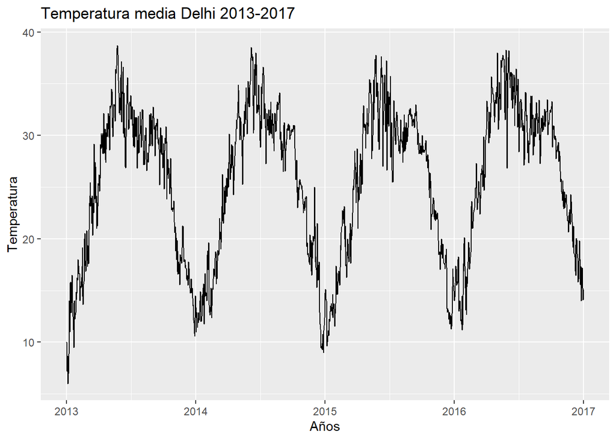

```r
temp_train_ts %>%
  autoplot(meantemp) +
    labs(title = "Temperatura media Delhi 2013-2017") +
    xlab("Años") + ylab("Temperatura")
```

A simple vista podemos ver cierto componente estacional en las temperaturas que se registran año a año, y una leve tendencia positiva.

## 3.1. Estacionariedad

Observando el gráfico parece que hay una componente estacional anual, ya que la forma de las series anuales son iguales.

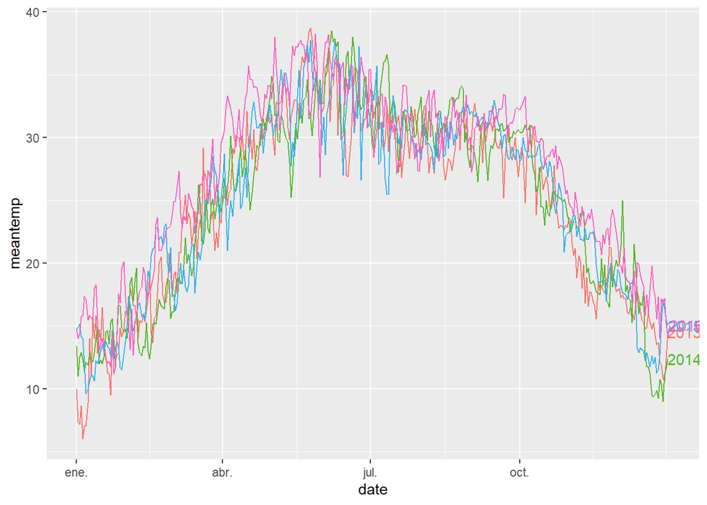

```r
temp_train_ts%>%
gg_season(meantemp, labels = "right")
```

Calculamos la descomposición STL para observar si existe tendencia y estacionalidad. Gráficamente se puede comprobar que existe estacionalidad y una tendencia creciente.Por tanto, parece que se puede decir que la serie no es estacionaria en media.

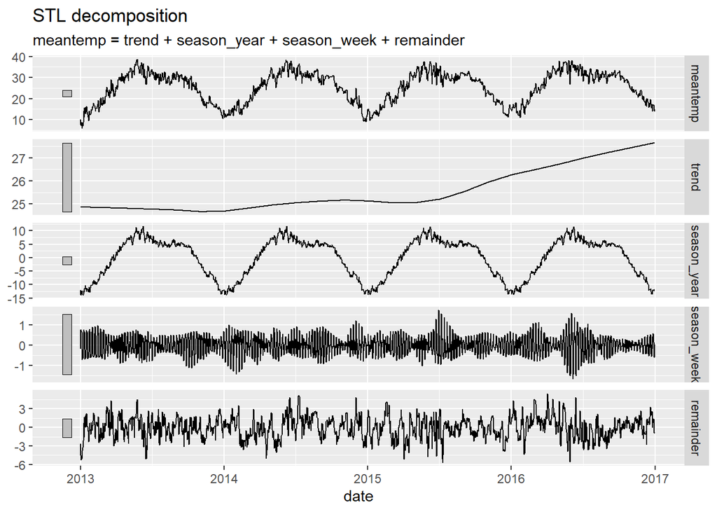

```r
temp_train_ts %>%
   model(seats = feasts:::STL(meantemp)) %>%
  components() %>%
  autoplot()
```

### 3.1.1. Estacionariedad en Varianza

Ahora estudiamos la estacionariedad en varianza. Dado que obtenemos un valor muy próximo a 1, no realizaremos ningún cambio o transformación Box-Cox para ajustar la varianza y estabilizarla, ya que como podemos observar si se aprecia estacionariedad en varianza.

```r
lambda <- temp_train_ts %>%
features(meantemp, features = guerrero) %>% pull(lambda_guerrero)
lambda
```

```
## [1] 0.8396361
```

### 3.1.2. Estacionariedad en Media

Comprobamos la estacionariedad en media usando una prueba de raíces unitarias.

```r
temp_train_ts %>%
  features(meantemp, unitroot_kpss)
```

```
## # A tibble: 1 x 2
##   kpss_stat kpss_pvalue
##       <dbl>       <dbl>
## 1     0.589      0.0236
```

El p-valor es menor que 0.05, lo que indica que la hipótesis nula es rechazada. Es decir, los datos no son estacionarios en media. Se confirma formalmente que los datos no son estacionarios.

Para estabilizar la media usamos una diferencia y lo comprobamos con el siguiente test. Obtenemos un p_value mayor de 0.05 por lo que cumpliría la hipótesis de estacionariedad y podemos realizar una diferencia regular para eliminar la tendencia.

```r
temp_train_ts %>%
  features(difference(meantemp, 1), unitroot_kpss)
```

```
## # A tibble: 1 x 2
##   kpss_stat kpss_pvalue
##       <dbl>       <dbl>
## 1     0.128         0.1
```

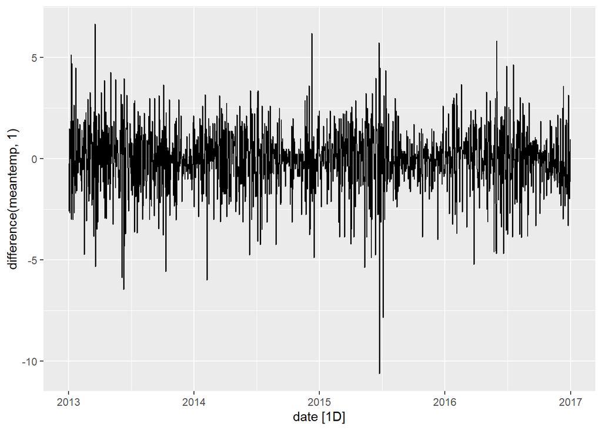

```r
temp_train_ts %>% autoplot(difference(meantemp, 1))
```

Para evaluar si es necesario realizar una diferencia estacional debido a que los datos presentan estacionalidad usaremos unitroot_nsdiffs(). Debido a que es menor a 0.64 el método no sugiere una diferencia estacional.

```r
temp_train_ts %>%
  mutate(turnover = difference(meantemp,1)) %>%
  features(turnover, unitroot_nsdiffs)
```

```
## # A tibble: 1 x 1
##   nsdiffs
##     <int>
## 1       0
```

## 3.2. Creación del modelo (determinación, estimación y contraste)

Creamos las funciones auxiliares que nos servirán para la creación y evaluación del modelo.

```r
# Contraste para los coeficientes
my_t_test <- function (object, ...)
{
  par <- rbind(t_stat=tidy(object)$statistic, p_value=tidy(object)$p.value)
  colnames(par) <- tidy(object)$term
  if (NCOL(par) > 0) {
    cat("\nt-test:\n")
    coef <- round(par, digits = 4)
    print.default(coef, print.gap = 2)
  }
}

# Gráfico de correlogramas de residuos
my_tsresiduals <- function (data, ...) {
  if (!fabletools::is_mable(data)) {
    abort("gg_tsresiduals() must be used with a mable containing only one model.")
  }
  data <- stats::residuals(data)
  if (n_keys(data) > 1) {
    abort("gg_tsresiduals() must be used with a mable containing only one model.")
  }
  gg_tsdisplay(data, !!sym(".resid"), plot_type = "partial",
    ...)
}

# Validación cruzada anidada

nested_cv <- function(df, h, last_train, string_formula){

  nested_errors <- vector()

for (i in seq(last_train, last(df$date), h)){
  train <- df %>% filter(date<=i)
  test <- df %>% filter(date>i)

fitted_model <- train %>%
  model(arima = ARIMA(as.formula(string_formula)))

h_forecast = min(dim(test)[1], h)

fc <- fitted_model %>%
  forecast(h=h_forecast)

test_err <- fc %>%
  accuracy(test) %>%
  select(MAPE)
nested_errors <- c(nested_errors, test_err$MAPE)
NewList <- list("errors"=nested_errors, "mean"=mean(nested_errors))
}
return(NewList)}

# Test de autocorrelacines de los residuos
autocorrelation_test_plot <- function(aug, dof = 4, m = 7,  h = 5, alpha = 0.05){
vec <- c()
num_lags = seq(1, h*m)

for (i in num_lags){
 vec <- c(vec,aug %>% features(.resid, ljung_box, lag=i, dof=dof) %>% .$lb_pvalue)
}

autocorr_pvalues_resid <- tibble(
  lag = num_lags,
  p_value = vec,
  incorelated = p_value >= alpha
)

plot <- autocorr_pvalues_resid %>%
  drop_na() %>%
   ggplot(aes(lag, p_value, color = incorelated)) +
  geom_point() +
  geom_hline(aes(yintercept = alpha), linetype="dashed", color = "indianred2")


newList <- list("values" = autocorr_pvalues_resid, "plot" = plot)
return(newList)
}
```

### 3.2.1. Creación manual del modelo

En los pasos previos hemos detectado la necesidad de realizar una diferencia regular, pero no una estacional. Por tanto, comenzaremos con el ajuste de un modelo SARIMA (0,1,0)x(0,0,0)[7], sobre la serie.

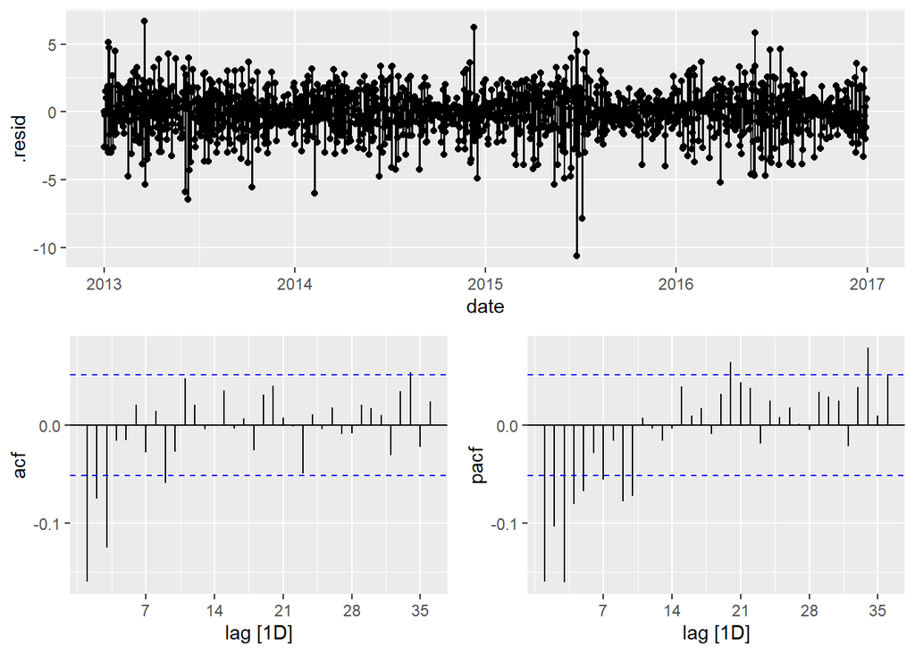

```r
fit <- temp_train_ts %>%
  model(arima = ARIMA(meantemp ~ pdq(0,1,0) + PDQ(0,0,0, period = 7)))
fit %>% my_tsresiduals(lag_max = 36)
```

Viendo los resultados obtenidos en las gráficas de acf y pacf, empezamos ajustando la serie temporal añadiendo al modelo un 1 en el parámetro “q” relativo a MA en la parte regular de la serie.

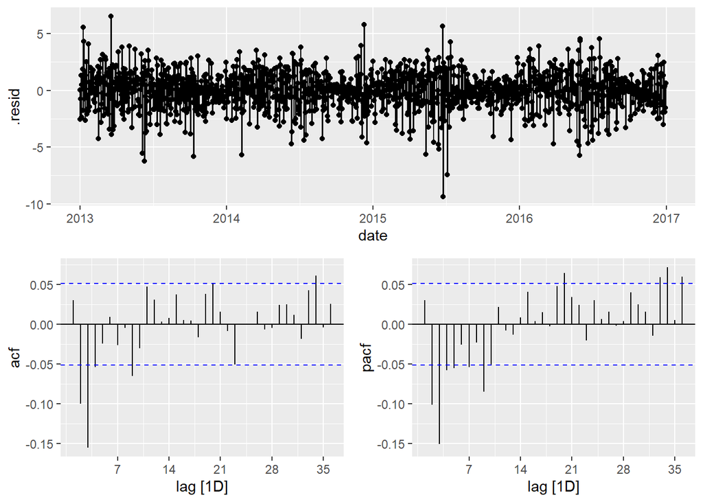

```r
fit1 <- temp_train_ts %>%
  model(arima = ARIMA(meantemp ~ pdq(0,1,1) + PDQ(0,0,0, period = 7)))
fit1 %>% my_tsresiduals(lag_max = 36)
```

Añadimos al modelo un 2 en el parámetro “q” relativo a MA en la parte regular de la serie, ya que observamos en las graficas acf/pacf como aún el segundo y tercer lag se salen de las bandas.

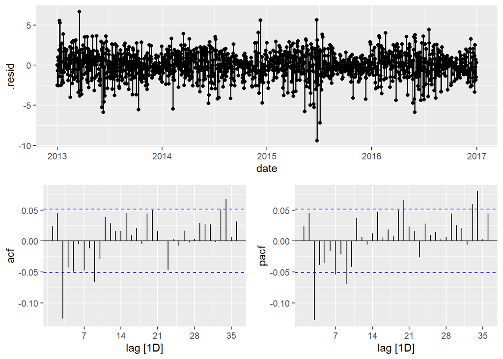

```r
fit1 <- temp_train_ts %>%
  model(arima = ARIMA(meantemp ~ pdq(0,1,2) + PDQ(0,0,0, period = 7)))
fit1 %>% my_tsresiduals(lag_max = 36)
```

Añadimos al modelo un 3 en el parámetro “q” relativo a MA en la parte regular de la serie, basándonos en los resultados obtenidos y viendp que el tercer lag en las gráficas de acf/pacf se sigue saliendo de las bandas.

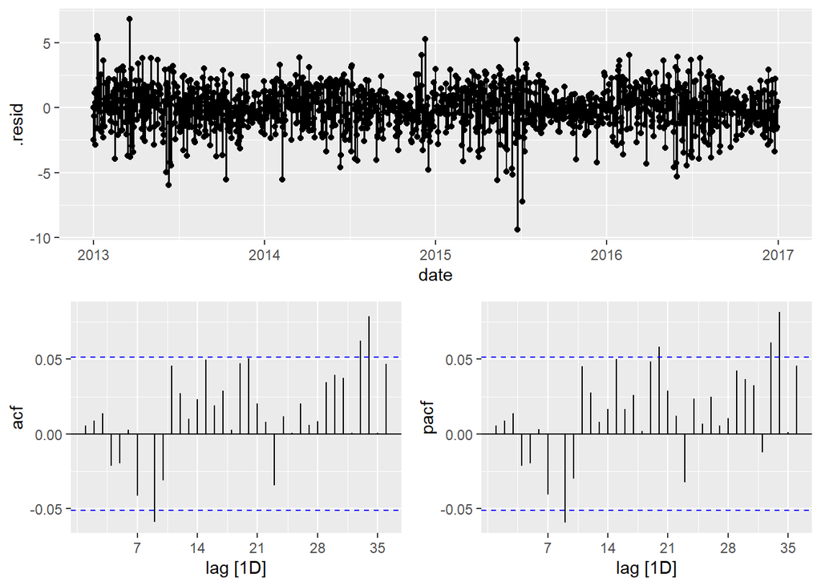

```r
fit1 <- temp_train_ts %>%
  model(arima = ARIMA(meantemp ~ pdq(0,1,3) + PDQ(0,0,0, period = 7)))
fit1 %>% my_tsresiduals(lag_max = 36)
```

Por último añadimos al modelo un 1 en el parámetro “P” relativo a AR en la parte estacional de la serie.

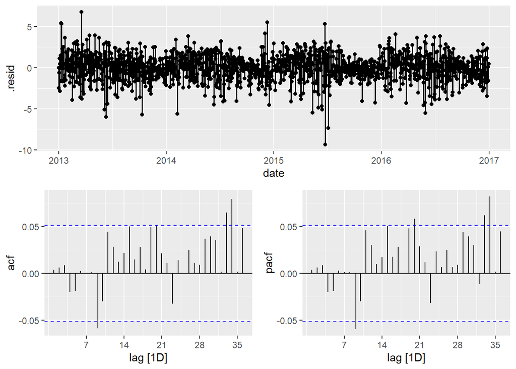

```r
fit1 <- temp_train_ts %>%
  model(arima = ARIMA(meantemp ~ pdq(0,1,3) + PDQ(1,0,0, period = 7)))
fit1 %>% my_tsresiduals(lag_max = 36)
```

Comprobemos la calidad estadística del modelo creado:

```r
report(fit1)
```

```
## Series: meantemp
## Model: ARIMA(0,1,3)(1,0,0)[7]
##
## Coefficients:
##           ma1      ma2      ma3     sar1
##       -0.2234  -0.1275  -0.1507  -0.0417
## s.e.   0.0259   0.0269   0.0256   0.0264
##
## sigma^2 estimated as 2.567:  log likelihood=-2757.97
## AIC=5525.94   AICc=5525.98   BIC=5552.37
```

```r
my_t_test(fit1)
```

```
##
## t-test:
##              ma1      ma2     ma3     sar1
## t_stat   -8.6338  -4.7428  -5.882  -1.5823
## p_value   0.0000   0.0000   0.000   0.1138
```

No es posible identificar más estructura a partir del ACF y PACF, no hay problemas de estacionariedad o invertibilidad. Vemos que todos los parámetros son significativos a excepción de SAR1, cuyo p.value es superior a 0.05. Algunas de las autocorrelaciones se siguen saliendo minimamente de las bandas.

### 3.2.2. Creación automática del modelo

Utilizamos la función de auto.arima para tratar de obtener un modelo ajustado a nuestra serie temporal generado de forma automática.

```r
#ajuste del modelo automatica

autoarima_model<- auto.arima(temp_train_ts)
autoarima_model
```

```
## Series: temp_train_ts
## ARIMA(3,1,2)(1,0,0)[7]
##
## Coefficients:
##          ar1     ar2      ar3      ma1      ma2     sar1
##       0.0937  0.2087  -0.0860  -0.3135  -0.3101  -0.0317
## s.e.  0.3635  0.2274   0.0325   0.3646   0.3088   0.0307
##
## sigma^2 = 2.568:  log likelihood = -2757.26
## AIC=5528.51   AICc=5528.59   BIC=5565.51
```

El resultado que obtenemos con la función es un SARIMA (3,1,2)x(1,0,0)[7].

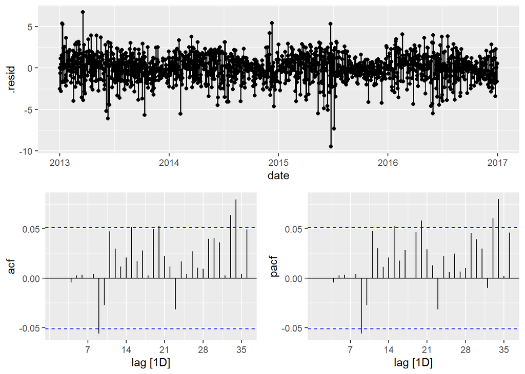

```r
fit2 <- temp_train_ts %>%
  model(arima = ARIMA(meantemp ~ pdq(3,1,2) + PDQ(1,0,0, period = 7)))
fit2 %>% my_tsresiduals(lag_max = 36)
```

```r
report(fit2)
```

```
## Series: meantemp
## Model: ARIMA(3,1,2)(1,0,0)[7]
##
## Coefficients:
##          ar1     ar2      ar3      ma1      ma2     sar1
##       0.0937  0.2087  -0.0860  -0.3135  -0.3101  -0.0317
## s.e.  0.3635  0.2274   0.0325   0.3646   0.3088   0.0307
##
## sigma^2 estimated as 2.568:  log likelihood=-2757.26
## AIC=5528.51   AICc=5528.59   BIC=5565.51
```

```r
my_t_test(fit2)
```

```
##
## t-test:
##             ar1     ar2      ar3      ma1      ma2     sar1
## t_stat   0.2578  0.9175  -2.6455  -0.8598  -1.0042  -1.0346
## p_value  0.7966  0.3590   0.0082   0.3900   0.3155   0.3010
```

Vemos que la mayor parte de los parámetros no son significativos a excepción de AR3, cuyo p.value es inferior a 0.05.

## 3.3. Diagnosis de residuos del modelo final

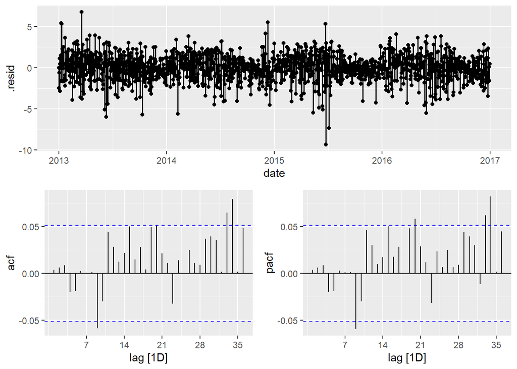

```r
fit4 <- temp_train_ts %>%
  model(arima = ARIMA(meantemp ~ pdq(0,1,3) + PDQ(1,0,0, period = 7)))
fit4 %>% my_tsresiduals(lag_max = 36)
```

**TEST NORMALIDAD:**

Para completar la fase de contraste del modelo evaluamos sus residuos.

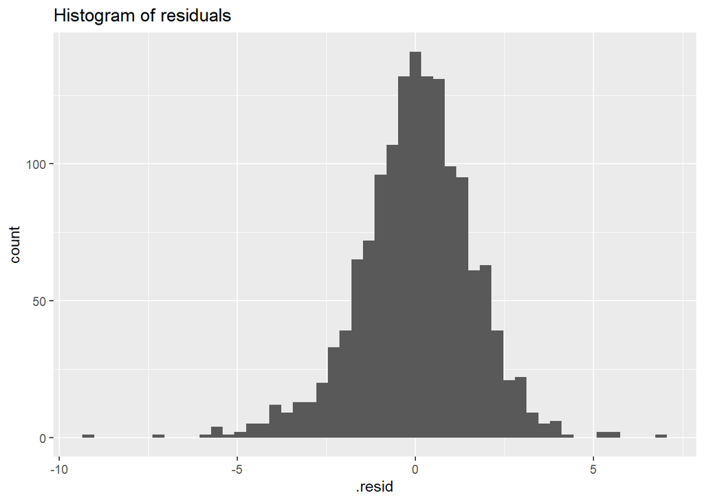

```r
aug <-fit4 %>% augment()

# Histogram
aug %>%
  ggplot(aes(x = .resid)) +
  geom_histogram(bins = 50) +
  ggtitle("Histogram of residuals")
```

Observando el histograma relativo a los residuos del modelo podemos ver que parece que la media es cero y que sigue medianamente una distribución normal.

Realizamos un test de T-Student para contrastar si realmente la media es cero.

```r
t.test(aug$.resid)
```

```
##
##  One Sample t-test
##
## data:  aug$.resid
## t = 0.20445, df = 1460, p-value = 0.838
## alternative hypothesis: true mean is not equal to 0
## 95 percent confidence interval:
##  -0.07355211  0.09066786
## sample estimates:
##   mean of x
## 0.008557875
```

Como p-value > 0.05 no podemos rechazar la hipótesis de que la muestra tiene media 0.

**TEST AUTOCORRELACIONES:**

Ahora intentamos comprobar con un test de Ljung-Box que los residuos están incorrelados a través de un test de autocorrelación.

```
## $values
## # A tibble: 35 x 3
##      lag p_value incorelated
##    <int>   <dbl> <lgl>
##  1     1 NaN     NA
##  2     2 NaN     NA
##  3     3 NaN     NA
##  4     4   0     FALSE
##  5     5   0.262 TRUE
##  6     6   0.530 TRUE
##  7     7   0.736 TRUE
##  8     8   0.866 TRUE
##  9     9   0.278 TRUE
## 10    10   0.269 TRUE
## # ... with 25 more rows
##
## $plot
```

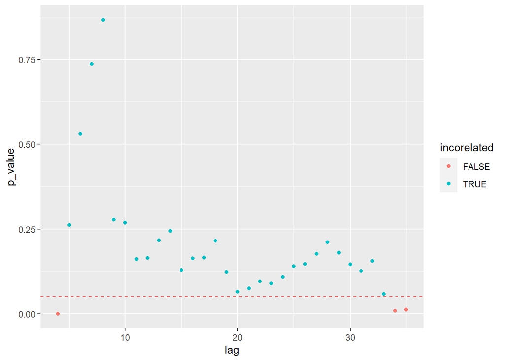

```r
pvals = autocorrelation_test_plot(aug, dof = 4, m = 7,  h = 5, alpha = 0.05)
pvals
```

Los p-valores son mayores de 0.05 en la mayoría de las autocorrelaciones. Por lo tanto, podemos concluir que los residuos no están correlados.

**TEST HOMOCEDASTICIDAD:**

```r
log_log <- aug %>% as_tibble() %>%
  group_by(week(date)) %>%
  summarize(mean_resid = log(mean(.resid+1)), std_resid = log(sd(.resid+1)))
```

```r
summary(lm(std_resid~mean_resid, log_log))
```

```
##
## Call:
## lm(formula = std_resid ~ mean_resid, data = log_log)
##
## Residuals:
##      Min       1Q   Median       3Q      Max
## -0.76242 -0.15093  0.01077  0.19050  0.55397
##
## Coefficients:
##             Estimate Std. Error t value Pr(>|t|)
## (Intercept)  0.37742    0.03948   9.560 5.85e-13 ***
## mean_resid  -0.01611    0.07267  -0.222    0.825
## ---
## Signif. codes:  0 '***' 0.001 '**' 0.01 '*' 0.05 '.' 0.1 ' ' 1
##
## Residual standard error: 0.2829 on 51 degrees of freedom
## Multiple R-squared:  0.0009632,  Adjusted R-squared:  -0.01863
## F-statistic: 0.04917 on 1 and 51 DF,  p-value: 0.8254
```

Como el p-valor de log(media) es grande, entonces no puede considerarse distinto de 0 y por tanto los residuos son homocedásticos (varianza de los errores es constante).

## 3.4. Predicción con el modelo final

Antes de nada, unimos los dataset de train y test que teníamos separados para crear uno total de la serie temporal completa.

```r
clima_total<-merge(x=clima_train,y=clima_test,all = TRUE)
head(clima_total)
```

```
##         date  meantemp humidity wind_speed meanpressure
## 1 2013-01-01 10.000000 84.50000   0.000000     1015.667
## 2 2013-01-02  7.400000 92.00000   2.980000     1017.800
## 3 2013-01-03  7.166667 87.00000   4.633333     1018.667
## 4 2013-01-04  8.666667 71.33333   1.233333     1017.167
## 5 2013-01-05  6.000000 86.83333   3.700000     1016.500
## 6 2013-01-06  7.000000 82.80000   1.480000     1018.000
```

El dataset creado con los datos totales lo pasamos a tsibble

```r
temp_total <- clima_total[,c(1,2)]
head(temp_total)
```

```
##         date  meantemp
## 1 2013-01-01 10.000000
## 2 2013-01-02  7.400000
## 3 2013-01-03  7.166667
## 4 2013-01-04  8.666667
## 5 2013-01-05  6.000000
## 6 2013-01-06  7.000000
```

```r
temp_total_ts<- as_tsibble(temp_total, index = date)

temp_total_ts
```

```
## # A tsibble: 1,575 x 2 [1D]
##    date       meantemp
##    <date>        <dbl>
##  1 2013-01-01    10
##  2 2013-01-02     7.4
##  3 2013-01-03     7.17
##  4 2013-01-04     8.67
##  5 2013-01-05     6
##  6 2013-01-06     7
##  7 2013-01-07     7
##  8 2013-01-08     8.86
##  9 2013-01-09    14
## 10 2013-01-10    11
## # ... with 1,565 more rows
```

Comenzamos a realizar la predicción con el modelo final y a evaluar su capacidad predictiva. Calculamos las predicciones en el conjunto de test, calculamos sus errores y los comparamos con los residuos.

```r
# Residual accuracy
resids <- fit4 %>%
  accuracy() %>%
  dplyr::select(-c(.model, .type, ME, MPE, ACF1, RMSSE)) %>%
  mutate(Evaluation='Training')

# Forecasting
fc <- fit4 %>%
  forecast(h=7)

test_err <- fc %>%
  accuracy(temp_total_ts) %>%
  dplyr::select(-c(.model, .type, ME, MPE, ACF1, RMSSE)) %>%
  mutate(Evaluation='Test')

# Show errors together
bind_rows(test_err, resids) %>% dplyr::select(Evaluation, everything())
```

```
## # A tibble: 2 x 5
##   Evaluation  RMSE   MAE  MAPE  MASE
##   <chr>      <dbl> <dbl> <dbl> <dbl>
## 1 Test        2.50  2.21 12.2  0.944
## 2 Training    1.60  1.21  5.26 0.518
```

Tratamos de evaluar también año a año la serie temporal real con la predicha para evaluar así los errores, detectar atípicos y analizar efectos de calendario sobre la misma.

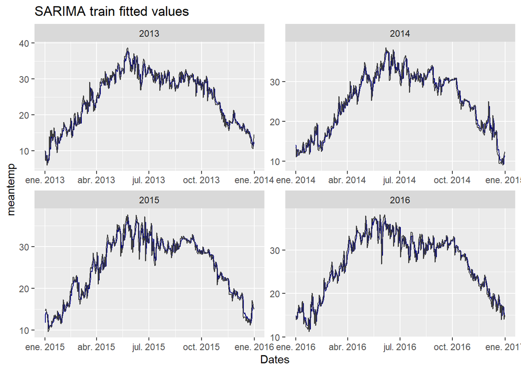

```r
aug %>%  ggplot() +
  geom_line(aes(x = date, y = .fitted), color="navy") +
  geom_line(aes(x = date, y = meantemp), color="gray24") +
  # geom_line(data=demandaGas_forecast, aes(x = index, y = value), color="red4") +
  ggtitle("SARIMA train fitted values") +
  xlab('Dates') +
  ylab('meantemp') + facet_wrap(vars(year(date)), scales = 'free')
```

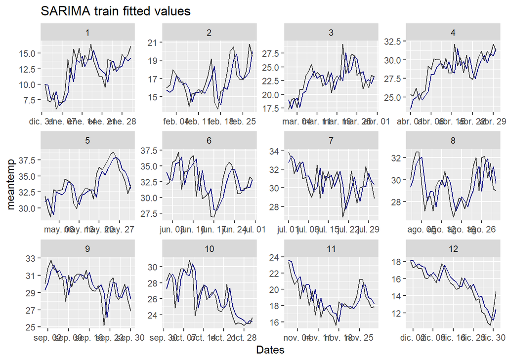

```r
aug %>% filter(year(date) == 2013) %>%
  ggplot() +
  geom_line(aes(x = date, y = .fitted), color="navy") +
  geom_line(aes(x = date, y = meantemp), color="gray24") +
  # geom_line(data=demandaGas_forecast, aes(x = index, y = value), color="red4") +
  ggtitle("SARIMA train fitted values") +
  xlab('Dates') +
  ylab('meantemp') + facet_wrap(vars(month(date)), scales = 'free')
```

Vemos en los gráficos mensuales mostrados como hay un problema en la predicción de la serie, mostrando un cierto retardo en la estimación de los valores.

Para finalmente tratar de ver la capacidad predictora del modelo, transformamos el dataset con los datos de test a tsibble.

```r
temp_test <- clima_test[,c(1,2)]
head(temp_train)
```

```
##         date  meantemp
## 1 2013-01-01 10.000000
## 2 2013-01-02  7.400000
## 3 2013-01-03  7.166667
## 4 2013-01-04  8.666667
## 5 2013-01-05  6.000000
## 6 2013-01-06  7.000000
```

```r
temp_test_ts<- as_tsibble(temp_test, index = date)

temp_test_ts
```

```
## # A tsibble: 114 x 2 [1D]
##    date       meantemp
##    <date>        <dbl>
##  1 2017-01-01     15.9
##  2 2017-01-02     18.5
##  3 2017-01-03     17.1
##  4 2017-01-04     18.7
##  5 2017-01-05     18.4
##  6 2017-01-06     19.3
##  7 2017-01-07     14.7
##  8 2017-01-08     15.7
##  9 2017-01-09     14.6
## 10 2017-01-10     12.1
## # ... with 104 more rows
```

Analizamos la capacidad predictora del modelo y sus intervalos de confianza.

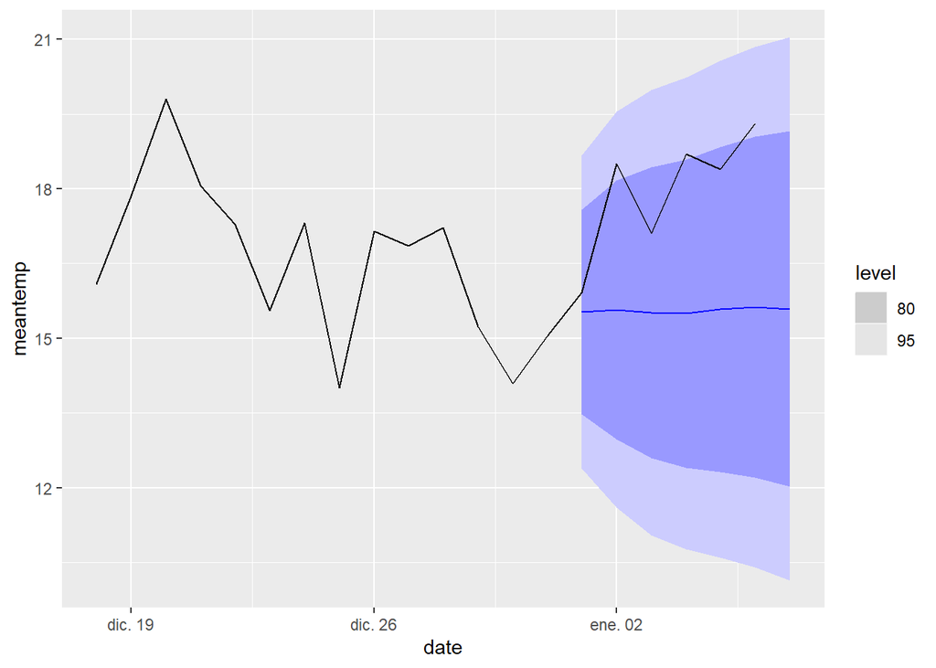

```r
h <- dim(temp_test_ts)[1]

demanda_plot <- temp_total_ts %>% filter(date>last(temp_train_ts$date)-14 & date< last(temp_train_ts$date) + 7 )

fit4 %>%
  forecast(h=7) %>%
  autoplot(demanda_plot)
```

Vemos que la capacidad predictora de nuestro modelo es mala en el periodo de 7 días analizado. Tenemos una serie con multiestacionalidad y un modelo que no está siendo capaz de captarla y representarla, por lo que las predicciones que obtenemos no son las deseadas. Deberíamos tratar de utilizar técnicas y modelos más complejos que traten de ajustarse de mejor forma a las características de nuestra serie.

# 4. Modelo de Naive Bayes estacional

Para tratar de comparar el modelo SARIMA creado con alguna alternativa que nos permita realizar una mejor predicción, desarrollamos un modelo Naive Bayes estacional para nuestra serie.

Inicialmente convertimos los datos de nuestra serie temporal estacional a TS.

```r
ts_train_ts <- ts(temp_train$meantemp, start = c(2013,1), frequency=365)
head(ts_train_ts)
```

```
## Time Series:
## Start = c(2013, 1)
## End = c(2013, 6)
## Frequency = 365
## [1] 10.000000  7.400000  7.166667  8.666667  6.000000  7.000000
```

A través de la función Window cogemos la venta temporal sobre la que queremos realizar la predicción con el modelo de Bayes.

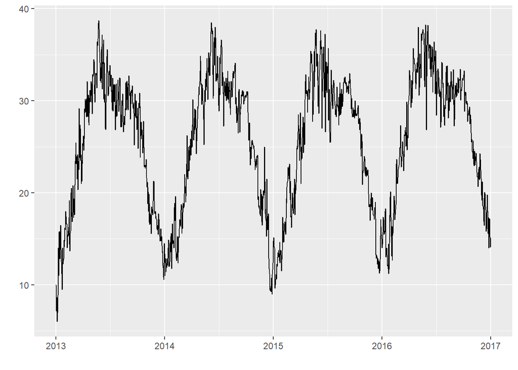

```r
ts_naive <- window(ts_train_ts,start=c(2013,1),end=c(2017,1))

autoplot(ts_naive)
```

Con la función SNAIVE y los datos de la serie ya transformados a TS, creamos el modelo de Naive Bayes estacional para realizar la predicción de los datos.

```r
ts_naive_forecast <- snaive(ts_naive ,h=114)
head(ts_naive_forecast)
```

[output not shown]

[output cut: 724 more lines]

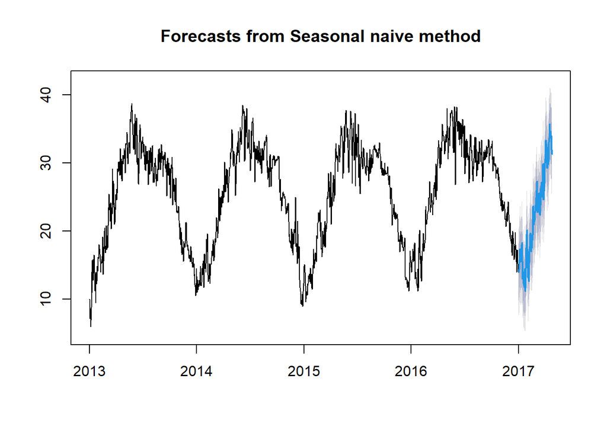

```r
plot(ts_naive_forecast)
```

```r
ts_total_ts <- ts(temp_total$meantemp, start = c(2013,1), frequency=365)
head(ts_total_ts)
```

```
## Time Series:
## Start = c(2013, 1)
## End = c(2013, 6)
## Frequency = 365
## [1] 10.000000  7.400000  7.166667  8.666667  6.000000  7.000000
```

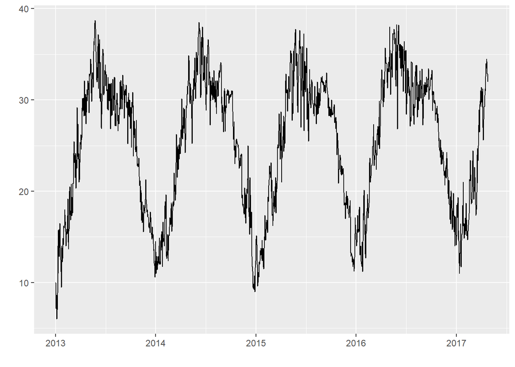

```r
autoplot(ts_total_ts)
```